# STATS 101C: HW 4

Eric Chuu (604406828)

April 19, 2017

## **Exercise 5.4.5**

#### a. Fit a logistic regression model that uses income and balance to predict default.

```r
glm.default = glm(default ~ income + balance, data = Default, family = binomial)
summary(glm.default) # income, balance both significant
```

```
##
## Call:
## glm(formula = default ~ income + balance, family = binomial,
##     data = Default)
##
## Deviance Residuals:
##     Min       1Q   Median       3Q      Max
## -2.4725  -0.1444  -0.0574  -0.0211   3.7245
##
## Coefficients:
##               Estimate Std. Error z value Pr(>|z|)
## (Intercept) -1.154e+01  4.348e-01 -26.545  < 2e-16 ***
## income       2.081e-05  4.985e-06   4.174 2.99e-05 ***
## balance      5.647e-03  2.274e-04  24.836  < 2e-16 ***
## ---
## Signif. codes:  0 '***' 0.001 '**' 0.01 '*' 0.05 '.' 0.1 ' ' 1
##
## (Dispersion parameter for binomial family taken to be 1)
##
##     Null deviance: 2920.6  on 9999  degrees of freedom
## Residual deviance: 1579.0  on 9997  degrees of freedom
## AIC: 1585
##
## Number of Fisher Scoring iterations: 8
```

```r
default.probs = predict(glm.default, type = "response");
glm.pred = rep("No", dim(Default)[1])
glm.pred[default.probs > 0.5] = "Yes";
conf_mat = table(glm.pred, Default$default)
train_acc = round(mean(glm.pred == Default$default), 4)
```

The training accuracy is 0.9737 using logistic regression on the entire dataset.

#### b, c. The function below fits a logistic regression model using the validation set approach.

```r
n_obs = dim(Default)[1]
train_logistic = function() {
  train = sample(n_obs, n_obs/2);

  dft_train_fit = glm(default ~ income + balance, data = Default,
                      subset = train, family = binomial)
  test_default = Default[-train,]
  test.probs = predict(dft_train_fit, test_default, type = "response");
  def_pred = rep("No", length(train));
  def_pred[test.probs > 0.5] = "Yes";
  test_err = round(mean(def_pred != Default$default[-train]), 4)
  test_err
}

set.seed(123)
e1 = train_logistic() # 0.0286
# (c) use different splits of train/validation
set.seed(234);
e2 = train_logistic() # 0.0256 error
set.seed(345);
e3 = train_logistic() # 0.027 error
```

Using the seeds 123, 234, and 345, we randomly split the training/validation sets and fit a logisitic regression model for each of these splits. The resulting testing errors were: 0.0286, 0.0256, and 0.027.

#### d. We then included the student variable as a dummy variable to see if the the testing errors would improve.

```r
train_logistic_1 = function() {
  train = sample(n_obs, n_obs/2);

  dft_train_fit = glm(default ~ income + balance + student, data = Default,
                      subset = train, family = binomial)
  test_default = Default[-train,]
  test.probs = predict(dft_train_fit, test_default, type = "response");
  def_pred = rep("No", length(train));
  def_pred[test.probs > 0.5] = "Yes";
  test_err = round(mean(def_pred != Default$default[-train]), 4)
  test_err
}

set.seed(123)
err1 = train_logistic_1() # 0.0284

set.seed(234);
err2 = train_logistic_1() # 0.0266

set.seed(345);
err3 = train_logistic_1() # 0.0274
```

Using the same seeds as before, the testing errors were: 0.0284, 0.0266, and 0.0274. The testing errors did not decrease when we added the student dummy variable.

## **Exercise 5.4.7**

#### (a) We first fit a logistic regression model that predicts Direction using Lag1 and Lag2. We see that Lag2 is significant.

```r
# (a) logistic regression model that predicts Direction using Lag1, Lag2
glm_dir0 = glm(Direction ~ Lag1 + Lag2, data = Weekly, family = binomial)
summary(glm_dir0)
```

```
##
## Call:
## glm(formula = Direction ~ Lag1 + Lag2, family = binomial, data = Weekly)
##
## Deviance Residuals:
##    Min      1Q  Median      3Q     Max
## -1.623  -1.261   1.001   1.083   1.506
##
## Coefficients:
##             Estimate Std. Error z value Pr(>|z|)
## (Intercept)  0.22122    0.06147   3.599 0.000319 ***
## Lag1        -0.03872    0.02622  -1.477 0.139672
## Lag2         0.06025    0.02655   2.270 0.023232 *
## ---
## Signif. codes:  0 '***' 0.001 '**' 0.01 '*' 0.05 '.' 0.1 ' ' 1
##
## (Dispersion parameter for binomial family taken to be 1)
##
##     Null deviance: 1496.2  on 1088  degrees of freedom
## Residual deviance: 1488.2  on 1086  degrees of freedom
## AIC: 1494.2
##
## Number of Fisher Scoring iterations: 4
```

#### (b) We first fit a logistic regression model that predicts Direction using Lag1 and Lag 2, using all but the first observation.

```r
# (b) predict direction using all but first obs
glm_dir1 = glm(Direction ~ Lag1 + Lag2, data = Weekly[-1,], family = binomial)
summary(glm_dir1)
```

```
##
## Call:
## glm(formula = Direction ~ Lag1 + Lag2, family = binomial, data = Weekly[-1,
##     ])
##
## Deviance Residuals:
##     Min       1Q   Median       3Q      Max
## -1.6258  -1.2617   0.9999   1.0819   1.5071
##
## Coefficients:
##             Estimate Std. Error z value Pr(>|z|)
## (Intercept)  0.22324    0.06150   3.630 0.000283 ***
## Lag1        -0.03843    0.02622  -1.466 0.142683
## Lag2         0.06085    0.02656   2.291 0.021971 *
## ---
## Signif. codes:  0 '***' 0.001 '**' 0.01 '*' 0.05 '.' 0.1 ' ' 1
##
## (Dispersion parameter for binomial family taken to be 1)
##
##     Null deviance: 1494.6  on 1087  degrees of freedom
## Residual deviance: 1486.5  on 1085  degrees of freedom
## AIC: 1492.5
##
## Number of Fisher Scoring iterations: 4
```

#### (c) We then use the model from part (b) to predict the Direction of the first observation.

```r
# (c) use model from part (b) to predict direction of first obs
ob1.prob = predict(glm_dir1, Weekly[1,], type = "response") > 0.5 # TRUE
Weekly[1,]$Direction # Down -> incorrectly classified
```

```
## [1] Down
## Levels: Down Up
```

Since the posterior probability for the first observation was greater 0.5, we predict that the Direction is Up, but upon looking at the true Direction, we see that it was actually Down. Our prediction was incorrect.

#### (d) We then simulate LOOCV using the for loop below.

```r
n = dim(Weekly)[1]
err = rep(0, n);
for (i in c(1:n)) {
  train = Weekly[-i,] # leave out i-th observation

  # train model using the new training set
  train.fit = glm(Direction ~ Lag1 + Lag2, data = train, family = binomial)
  # predict i-th  observation
  pred_i = predict(train.fit, Weekly[i,], type = "response") > 0.5
  if (pred_i == TRUE) {
    dir = "Up"
  } else {
    dir = "Down"
  }
  # store indicator for error
  err[i] = as.numeric((dir != Weekly[i,]$Direction))
}
total_errors = sum(err); # 490
avg_error    = round(mean(err), 4) # 0.45
```

#### (e) Averaging the errors for the $n = 1089$ errors from each of the iterations of LOOCV, we get 0.45 as an estimate for the test error. Using LOOCV, we are able to obtain estimate for the test error that is lower in variance, but it comes at the cost of computational complexity. Since only left one observation out during, then we had to train $n$ logisitic regression models, which would not scale if the model became very complex. For this dataset, we see that our prediction accuracy is better than chance - approximately 0.55.

## **Exercise 5.4.8**

#### (a) We first generate the data. In this case, $n = 100$ observations, $p = 1$ predictor. The model used to generate the data in equation form is:

$$Y = X - 2X^2 + \varepsilon$$

```r
set.seed(1)
y = rnorm(100)
x = rnorm(100)
y = x - 2 * x^2 + rnorm(100)
```

#### (b) The scatterplot of the data is given below. We notice that the plot is quadratic, with $x$ values ranging from -2 to 2 and $y$ values ranging from about -9 to 3.

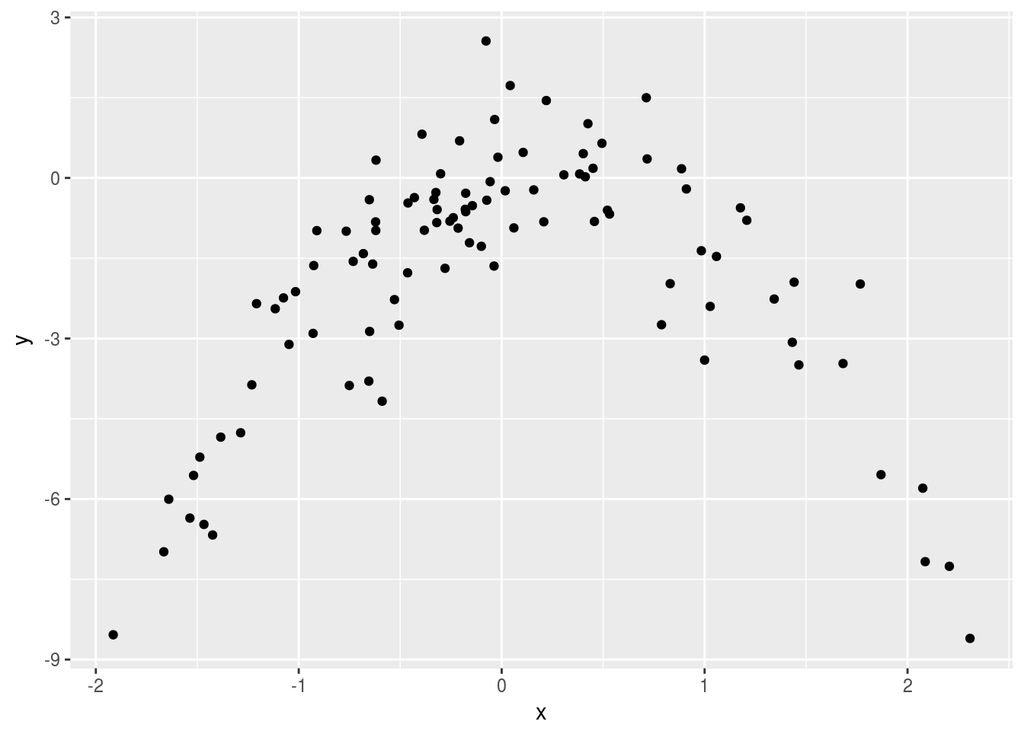

```r
d = data.frame(x, y)
ggplot(d, aes(x, y)) + geom_point() # quadratic plot, where x in [-2, 2]
```

#### (c) We set a seed and then compute the LOOCV errors that result from fitting the four models.

```r
set.seed(11)
cv_err = rep(0, 4);
for (i in c(1:4)) {
  fit_order_i = glm(y ~ poly(x, i), data = d);
  cv_err[i] = cv.glm(d, fit_order_i)$delta[1];
}
cv_err = round(cv_err, 4)
```

The errors are given for the four models are given from order 1 to order 4: 5.891, 1.0866, 1.1026, and 1.1148.

#### (d) We set a different seed and repeat the process, and we see that the results are the same. This is because LOOCV doesn’t use randomness. We simply iterate down the rows of the dataset, leaving one row out at a time. This process is not influenced by setting a seed.

```r
set.seed(111)
cv_err1 = rep(0, 4);
for (i in c(1:4)) {
  fit_order_i = glm(y ~ poly(x, i), data = d);
  # uncomment line below to see summaries
  # print(summary(fit_order_i)$Coefficient);
  cv_err1[i] = cv.glm(d, fit_order_i)$delta[1];
}

round(cv_err1, 4)
```

```
## [1] 5.8910 1.0866 1.1026 1.1148
```

#### (e) The order 2 model gave the smallest LOOCV error with 1.0866, which is expected because we know the model is quadratic, so the order 2 model naturally would yield the best fit. Having higher order may give better training results, but upon exposure to testing data, the model that is most similar to the true model will give better testing results. This is clearly the case in this model.

#### (f) By looking at the summary table of each of the order 4 model below, we can see that the linear and quadratic terms are significant, while the others are not. This remains the case for the summary of the order 1, 2, 3 models as well (uncomment line in the loop in part (c,d) to see this). Once again, these results agree with the cross validation results because the model has both a linear and quadratic term, so the corresponding terms in the model should therefore be significant, which we observe to be true.

```r
summary(fit_order_i) # order 4 model
```

```
##
## Call:
## glm(formula = y ~ poly(x, i), data = d)
##
## Deviance Residuals:
##     Min       1Q   Median       3Q      Max
## -2.8914  -0.5244   0.0749   0.5932   2.7796
##
## Coefficients:
##             Estimate Std. Error t value Pr(>|t|)
## (Intercept)  -1.8277     0.1041 -17.549   <2e-16 ***
## poly(x, i)1   2.3164     1.0415   2.224   0.0285 *
## poly(x, i)2 -21.0586     1.0415 -20.220   <2e-16 ***
## poly(x, i)3  -0.3048     1.0415  -0.293   0.7704
## poly(x, i)4  -0.4926     1.0415  -0.473   0.6373
## ---
## Signif. codes:  0 '***' 0.001 '**' 0.01 '*' 0.05 '.' 0.1 ' ' 1
##
## (Dispersion parameter for gaussian family taken to be 1.084654)
##
##     Null deviance: 552.21  on 99  degrees of freedom
## Residual deviance: 103.04  on 95  degrees of freedom
## AIC: 298.78
##
## Number of Fisher Scoring iterations: 2
```